# Project: Investigate a Dataset - [noshowappointments-kagglev2-may-2016]

- Introduction
- Data Wrangling
- Exploratory Data Analysis
- Conclusions

## Introduction

### Dataset Description

> For this analysis, I have chosen the `nowshowappointments` dataset. Within this dataset there is a plethora of demographic information on patients that have schedueled appointments and have either show up or not. There is a total of 110527 rows and 14 columns. The 14 columns are as follows:

> > PatientID, AppointmentID, Gender, ScheduledDay, AppointmentDay, Age, Neighbourhood, Scholarship, Hipertention, Diabetes, Alcoholism, Handcap, SMS-Recieved, No-show.

> The significance of each column will depend on the questions being asked, but for a broad description, the first 2 columns, PatientID and AppointmentID, give idenfication numbers for the indiviual and the appointment itself, allowing for easy calculating and tracking. Columns Gender through Neighbourhood give valuable demographic information about each patient. Scholarship through Handicap provide insight into whether the patient has any pre-existing conditions. SMS-recieved gives details on whether the patient recieved a text reminding them of their appointment, and No-show states whether the patient showed up or not, "No" meaning they did show up and "Yes" meaning they did not.

### Question(s) for Analysis

> Q1: Does gender and age play a role in whether a patient shows up for an appointment?

```python
# Use this cell to set up import statements for all of the packages that you
#   plan to use.

import pandas as pd
import matplotlib.pyplot as plt

# While optional for current notebooks, if you are having trouble with visualizations,
#   remember to include a 'magic word' so that your visualizations are plotted
#   inline with the notebook. See this page for more:
#   http://ipython.readthedocs.io/en/stable/interactive/magics.html
```

## Data Wrangling

### General Properties

```python
# Load your data and print out a few lines. What is the size of your dataframe?
#   Perform operations to inspect data types and look for instances of missing
#   or possibly errant data. There are at least 4 - 6 methods you can call on your
#   dataframe to obtain this information.

df = pd.read_csv('noshowappointments-kagglev2-may-2016.csv')
```

```python
# Find the size of the dataset.

df.shape
```

```
(110527, 14)
```

```python
# Assess how the data is structured.

df.head()
```

|  | PatientId | AppointmentID | Gender | ScheduledDay | AppointmentDay | Age | Neighbourhood | Scholarship | Hipertension | Diabetes | Alcoholism | Handcap | SMS_received | No-show |
| --- | --- | --- | --- | --- | --- | --- | --- | --- | --- | --- | --- | --- | --- | --- |
| 0 | 2.987250e+13 | 5642903 | F | 2016-04-29T18:38:08Z | 2016-04-29T00:00:00Z | 62 | JARDIM DA PENHA | 0 | 1 | 0 | 0 | 0 | 0 | No |
| 1 | 5.589978e+14 | 5642503 | M | 2016-04-29T16:08:27Z | 2016-04-29T00:00:00Z | 56 | JARDIM DA PENHA | 0 | 0 | 0 | 0 | 0 | 0 | No |
| 2 | 4.262962e+12 | 5642549 | F | 2016-04-29T16:19:04Z | 2016-04-29T00:00:00Z | 62 | MATA DA PRAIA | 0 | 0 | 0 | 0 | 0 | 0 | No |
| 3 | 8.679512e+11 | 5642828 | F | 2016-04-29T17:29:31Z | 2016-04-29T00:00:00Z | 8 | PONTAL DE CAMBURI | 0 | 0 | 0 | 0 | 0 | 0 | No |
| 4 | 8.841186e+12 | 5642494 | F | 2016-04-29T16:07:23Z | 2016-04-29T00:00:00Z | 56 | JARDIM DA PENHA | 0 | 1 | 1 | 0 | 0 | 0 | No |

```python
# Check how many unique entries exist.

df.nunique()
```

```
PatientId          62299
AppointmentID     110527
Gender                 2
ScheduledDay      103549
AppointmentDay        27
Age                  104
Neighbourhood         81
Scholarship            2
Hipertension           2
Diabetes               2
Alcoholism             2
Handcap                5
SMS_received           2
No-show                2
dtype: int64
```

```python
# Check for any duplicated entries.

df.duplicated().any()
```

```
False
```

```python
# Check for missing values and datatypes.

df.info()
```

```
<class 'pandas.core.frame.DataFrame'>
RangeIndex: 110527 entries, 0 to 110526
Data columns (total 14 columns):
 #   Column          Non-Null Count   Dtype
---  ------          --------------   -----
 0   PatientId       110527 non-null  float64
 1   AppointmentID   110527 non-null  int64
 2   Gender          110527 non-null  object
 3   ScheduledDay    110527 non-null  object
 4   AppointmentDay  110527 non-null  object
 5   Age             110527 non-null  int64
 6   Neighbourhood   110527 non-null  object
 7   Scholarship     110527 non-null  int64
 8   Hipertension    110527 non-null  int64
 9   Diabetes        110527 non-null  int64
 10  Alcoholism      110527 non-null  int64
 11  Handcap         110527 non-null  int64
 12  SMS_received    110527 non-null  int64
 13  No-show         110527 non-null  object
dtypes: float64(1), int64(8), object(5)
memory usage: 11.8+ MB
```

> After my initial evaluation of the data, I can see that there are no duplicate entries and no missing values. Datatypes are in check and are not an issue. There are multiple entries of the same individuals as they make more appointments. The main issue is the excess amount of unwanted data that will need trimmed in order to answer my questions properly and inconsistent column names and misspellings.

### Data Cleaning

```python
# The main task will be to trim unwanted data.
# Start with removing any unwanted columns.

columns_to_drop = ['PatientId', 'AppointmentID', 'ScheduledDay', 'AppointmentDay', 'Scholarship',
                   'Hipertension', 'Diabetes', 'Alcoholism', 'Handcap', 'SMS_received']

for col in columns_to_drop:
    df.drop(col, axis=1, inplace=True)
```

```python
# Replace the hash mark in the No-show column to remove the
# possibility of errors.

df.rename(columns={'No-show': 'No_show'}, inplace=True)
df
```

|  | Gender | Age | Neighbourhood | No_show |
| --- | --- | --- | --- | --- |
| 0 | F | 62 | JARDIM DA PENHA | No |
| 1 | M | 56 | JARDIM DA PENHA | No |
| 2 | F | 62 | MATA DA PRAIA | No |
| 3 | F | 8 | PONTAL DE CAMBURI | No |
| 4 | F | 56 | JARDIM DA PENHA | No |
| ... | ... | ... | ... | ... |
| 110522 | F | 56 | MARIA ORTIZ | No |
| 110523 | F | 51 | MARIA ORTIZ | No |
| 110524 | F | 21 | MARIA ORTIZ | No |
| 110525 | F | 38 | MARIA ORTIZ | No |
| 110526 | F | 54 | MARIA ORTIZ | No |

110527 rows × 4 columns

```python
# Create a copy of the dataset to use for Q2.
# Drop Age and Gender Columns as they wont be needed for Q2.

neigh_noshow = df.copy()
neigh_noshow.drop(['Age', 'Gender'], axis=1, inplace=True)
```

> Creating a copy of the dataset will allow me to manipulate the data within the copy without running into CoW errors.

```python
# Drop the Neighbourhood column from the original dataset as it is not need for Q1.

df.drop('Neighbourhood', axis=1, inplace=True)
```

```python
# Query the dataset for unattended appointments.

df_noshows = df.query('No_show == "Yes"')
no_shows = df_noshows.groupby(['Gender', 'Age']).count()
no_shows.describe()
```

|  | No_show |
| --- | --- |
| count | 197.000000 |
| mean | 113.294416 |
| std | 80.285934 |
| min | 1.000000 |
| 25% | 46.000000 |
| 50% | 99.000000 |
| 75% | 175.000000 |
| max | 320.000000 |

```python
# Query the dataset for all appointments that were attended.

df_shows = df.query('No_show == "No"')
did_show = df_shows.groupby(['Gender', 'Age']).count()
did_show
```

| Gender | Age | No_show |
| --- | --- | --- |
| F | -1 | 1 |
|  | 0 | 1402 |
|  | 1 | 886 |
|  | 2 | 646 |
|  | 3 | 621 |
| ... | ... | ... |
| M | 95 | 4 |
|  | 96 | 4 |
|  | 97 | 1 |
|  | 98 | 1 |
|  | 100 | 2 |

204 rows × 1 columns

> In order to answer Q1, the table needed to be condensed down to Age, Gender, and whether the patient showed up or not. I then followed this up with querying for missed appointments and non-missed appointments, grouped by Gender and Age, allowing for a clean breakdown of each gender. This will make visualizations much easier to compare.

```python
# Query for "Yes" in No-show column and then groupby neighbourhood and total.
df_neigh_yes = neigh_noshow.query('No_show == "Yes"')
neigh_yes = df_neigh_yes.groupby('Neighbourhood').count()
neigh_yes
```

[output not shown]

```python
# Now query for "No" and repeat above.

df_neigh_no = neigh_noshow.query('No_show == "No"')
neigh_no = df_neigh_no.groupby('Neighbourhood').count()
neigh_no
```

[output not shown]

> Answering Q2 is a little more straight forward. I made a copy of the orgininal dataset and dropped all columns except Neighbourhood and No_show. I then queried the new set to isolate neighbourhoods where patients tend to show up to their appointments and where they don't.

## Exploratory Data Analysis

### Does gender and age play a role in whether a patient shows up for an appointment?

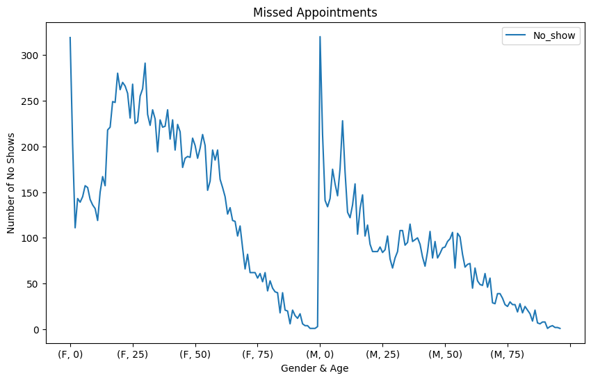

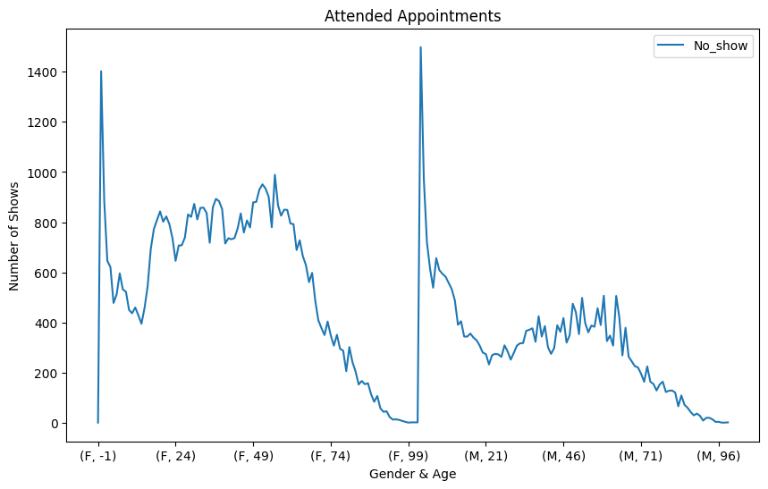

```python
# Combination graph to display trends for both male and female patients for both no shows and shows.

no_shows.plot(figsize=(10,6));
plt.title('Missed Appointments');
plt.xlabel('Gender & Age');
plt.ylabel('Number of No Shows');

did_show.plot(figsize=(10,6));
plt.title('Attended Appointments');
plt.xlabel('Gender & Age');
plt.ylabel('Number of Shows');
```

> When viewing both male and female data side by side, we can see that women tend to miss their appointments more than men, but the total amount of appointments remains higher as women age, resulting in higher odds of both, missed and not missed appointments.

### Which neighbourhood is associated with the highest no-show rate?

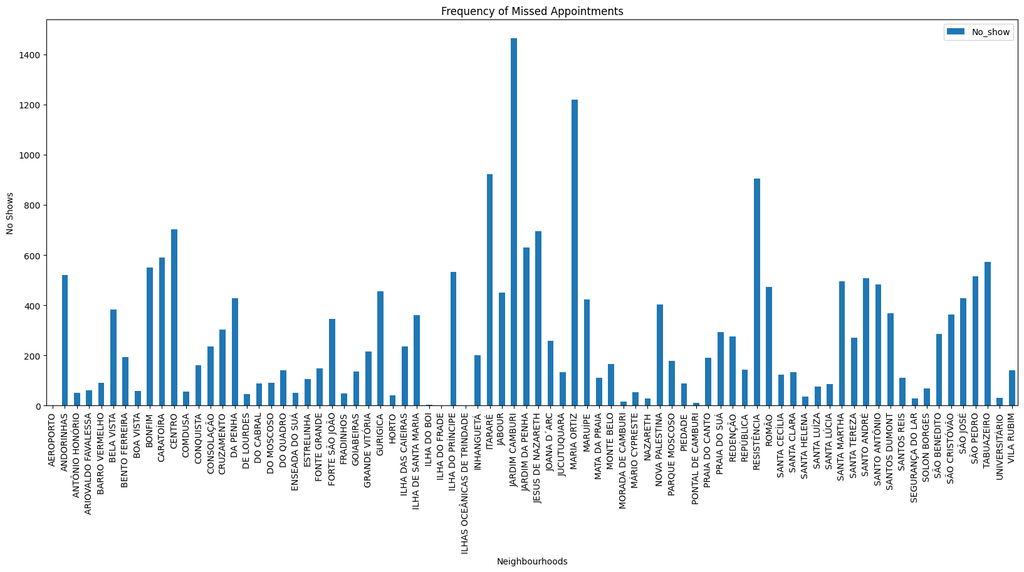

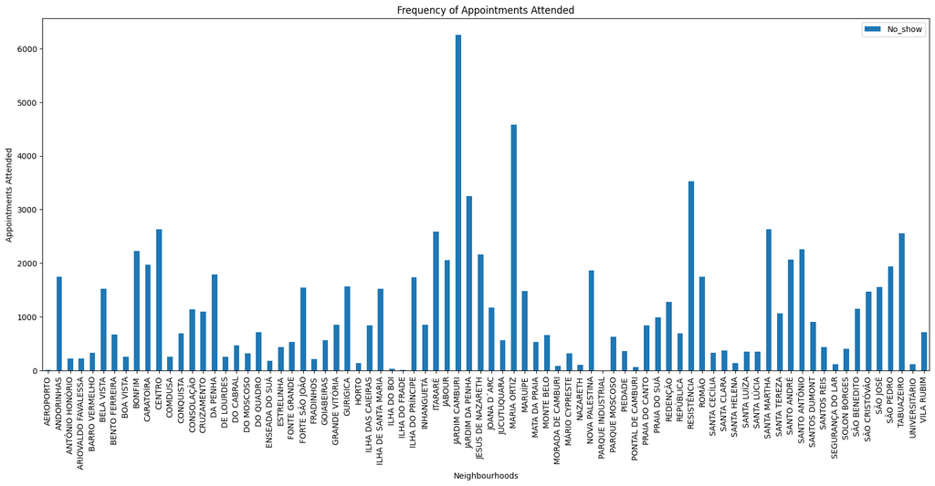

```python
# Plot data showing the frequency of no shows and attended appointments
#   based on neighbourhood.

neigh_yes.plot(kind='bar', figsize=(20,8));
plt.title('Frequency of Missed Appointments');
plt.ylabel('No Shows');
plt.xlabel('Neighbourhoods');
plt.xticks(rotation=90);

neigh_no.plot(kind='bar',figsize=(20,8));
plt.title('Frequency of Appointments Attended');
plt.ylabel('Appointments Attended');
plt.xlabel('Neighbourhoods');
```

```python
# Calculate the ratio of missed appointments for Jardim Camburi.

ratio = (neigh_yes.max() + neigh_no.max()) / neigh_yes.max()
ratio
```

```
No_show    5.267577
dtype: float64
```

## Conclusions

### Q1

> Throughout this analysis, I found that while both male and female patients tend to follow the same regression in terms of missing or attending their appointments, females tend to miss and attend more appointments within the 20-65 age bracket. That being said both genders tend to taper off in terms of overall appointment number as they get older. Additional research can be done through a more statistical lense by finding how specific each age group or gender plays a role on how many appointments are missed.

### Limitations

> A limitation for this analysis is the lack of informational data in reference to the objective of the data. The dataset has columns listing pre-existing conditions which is good information, but irrelevant for the goal of the data. Information on the reason behind why a patient missed would have allowed for a more indepth analysis to eventually begin to predict when a person might miss an appointment at the time they schedule it.

```python
# Running this cell will execute a bash command to convert this notebook to an .html file
!python -m nbconvert --to html Investigate_a_Dataset.ipynb
```